# Personal Activity

Leard Fernandes

Sunday, August 10, 2014

**Repository:** (https://github.com/leard/PersonalActivity2.git)

### Introduction

Using devices such as Jawbone Up, Nike FuelBand, and Fitbit it is now possible to collect a large amount of data about personal activity relatively inexpensively. These type of devices are part of the quantified self movement  a group of enthusiasts who take measurements about themselves regularly to improve their health, to find patterns in their behavior. People rarely quantify how well they do the exercise. In this data set, six young health participants were asked to perform one set of 10 repetitions of the Unilateral Dumbbell Biceps Curl in five different fashions: exactly according to the specification (Class A), throwing the elbows to the front (Class B), lifting the dumbbell only halfway (Class C), lowering the dumbbell only halfway (Class D) and throwing the hips to the front (Class E). Class A corresponds to the specified execution of the exercise, while the other 4 classes correspond to common mistakes.

### Data

The training data for this project are available here:

(https://d396qusza40orc.cloudfront.net/predmachlearn/pml-training.csv)

The test data are available here:

(https://d396qusza40orc.cloudfront.net/predmachlearn/pml-testing.csv)

The data for this project come from this source: (http://groupware.les.inf.puc-rio.br/har).

The loaded data set has many variables that are not necessary and with NA’s values. Removing the unecessary variables and showing:

```
## 'data.frame':    19622 obs. of  53 variables:
##  $ roll.belt           : num  1.41 1.41 1.42 1.48 1.48 1.45 1.42 1.42 1.43 1.45 ...
##  $ pitch.belt          : num  8.07 8.07 8.07 8.05 8.07 8.06 8.09 8.13 8.16 8.17 ...
##  $ yaw.belt            : num  -94.4 -94.4 -94.4 -94.4 -94.4 -94.4 -94.4 -94.4 -94.4 -94.4 ...
##  $ total.accel.belt    : int  3 3 3 3 3 3 3 3 3 3 ...
##  $ gyros.belt.x        : num  0 0.02 0 0.02 0.02 0.02 0.02 0.02 0.02 0.03 ...
##  $ gyros.belt.y        : num  0 0 0 0 0.02 0 0 0 0 0 ...
##  $ gyros.belt.z        : num  -0.02 -0.02 -0.02 -0.03 -0.02 -0.02 -0.02 -0.02 -0.02 0 ...
##  $ accel.belt.x        : int  -21 -22 -20 -22 -21 -21 -22 -22 -20 -21 ...
##  $ accel.belt.y        : int  4 4 5 3 2 4 3 4 2 4 ...
##  $ accel.belt.z        : int  22 22 23 21 24 21 21 21 24 22 ...
##  $ magnet.belt.x       : int  -3 -7 -2 -6 -6 0 -4 -2 1 -3 ...
##  $ magnet.belt.y       : int  599 608 600 604 600 603 599 603 602 609 ...
##  $ magnet.belt.z       : int  -313 -311 -305 -310 -302 -312 -311 -313 -312 -308 ...
##  $ roll.arm            : num  -128 -128 -128 -128 -128 -128 -128 -128 -128 -128 ...
```

[output cut: 39 more lines]

The training set contains 75% (14718 rows) of the data.

### Analysis

For the modeling was used the Stochastic Gradient Boosting, that improving the accuracy of a predictive function by applying the function repeatedly, where each function output is combined with weighting. Thus the total error of the prediction is minimized.

Before define the model, was created parameters for tunning the final model. For a gradient boosting machine (GBM) model, there are three main tuning parameters:

- number of iterations, i.e. trees, (called n.trees in the gbm function)
- complexity of the tree, called interaction.depth
- learning rate: how quickly the algorithm adapts, called shrinkage

- n.trees: (50, 100, 150, 200, 250, 300, 350, 400, 450, 500)
- interaction.depth: (4, 6, 12)
- shrinkage: 0.1

And, the second group has been configured

- n.trees: (50, 100, 150, 200, 250, 300, 350, 400, 450, 500, 550, 600, 650, 700, 750, 800, 850, 900, 950, 1000)
- interaction.depth: (4, 6, 12)
- shrinkage: 0.05

**GBM**

The model were previously calculated and loaded, because of the memory leak. Two groups of model were tunning. Was not used multiple values in fitControl, once the total memory used is too large. Thus the models has been splitted in six models.

```r
gbmPFit1.1<-readRDS("data/gbmPFit1.1.rds")
gbmPFit1.2<-readRDS("data/gbmPFit1.2.rds")
gbmPFit1.3<-readRDS("data/gbmPFit1.3.rds")
gbmPFit2.1<-readRDS("data/gbmPFit2.1.rds")
gbmPFit2.2<-readRDS("data/gbmPFit2.2.rds")
gbmPFit2.3<-readRDS("data/gbmPFit2.3.rds")
```

The two best models, using Kappa metric are:

```
##    shrinkage interaction.depth n.trees Accuracy  Kappa AccuracySD  KappaSD
## 30       0.1                12     500   0.9959 0.9948   0.001607 0.002033
```

```
##    shrinkage interaction.depth n.trees Accuracy Kappa AccuracySD  KappaSD
## 60      0.05                12    1000    0.996 0.995   0.001741 0.002203
```

Applying a tolerance of 1% and 2%, the new models for shrinkage 0.1 are, respectively:

```
##   shrinkage interaction.depth n.trees Accuracy  Kappa AccuracySD KappaSD
## 6       0.1                 4     300   0.9883 0.9852    0.00302 0.00382
```

```
##   shrinkage interaction.depth n.trees Accuracy  Kappa AccuracySD  KappaSD
## 4       0.1                 4     200   0.9813 0.9763   0.003686 0.004661
```

Applying a tolerance of 1% and 2%, the new models for shrinkage 0.05 are:

```
##    shrinkage interaction.depth n.trees Accuracy  Kappa AccuracySD  KappaSD
## 12      0.05                 4     600   0.9892 0.9863   0.002587 0.003273
```

```
##   shrinkage interaction.depth n.trees Accuracy  Kappa AccuracySD  KappaSD
## 8      0.05                 4     400   0.9822 0.9774   0.003403 0.004307
```

Combining the two models, the results for a tolerance of 1% and 2%:

```
##   shrinkage interaction.depth n.trees Accuracy  Kappa AccuracySD KappaSD
## 6       0.1                 4     300   0.9883 0.9852    0.00302 0.00382
```

```
##   shrinkage interaction.depth n.trees Accuracy  Kappa AccuracySD  KappaSD
## 4       0.1                 4     200   0.9813 0.9763   0.003686 0.004661
```

The models were recalculated with the chosen values. The model were previously calculated and loaded, because of the memory leak.

```r
gbmPFit1.4.1pct<-readRDS("data//gbmPFit1.4.1pct.rds")
gbmPFit1.4.2pct<-readRDS("data//gbmPFit1.4.2pct.rds")

gbmPFit2.4.1pct<-readRDS("data//gbmPFit2.4.1pct.rds")
gbmPFit2.4.2pct<-readRDS("data//gbmPFit2.4.2pct.rds")
```

The top 10 variables importance for all models

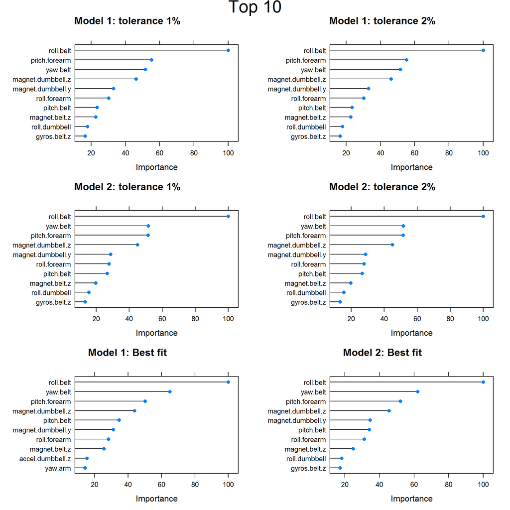

### Results

**Confusion Matrix for 1% tolerance for the first model**

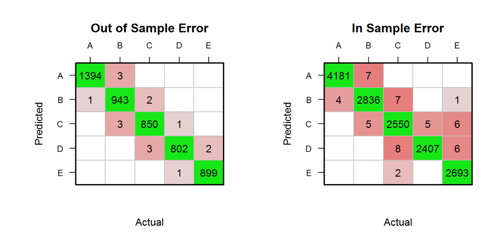

| Accuracy | Kappa | AccuracyLower | AccuracyUpper | AccuracyNull | AccuracyPValue | McnemarPValue |
| --- | --- | --- | --- | --- | --- | --- |
| 0.9967 | 0.9959 | 0.9947 | 0.9981 | 0.2849 | 0.0000 | NaN |

Table: Overall Statistics

|  | Class: A | Class: B | Class: C | Class: D | Class: E |
| --- | --- | --- | --- | --- | --- |
| Sensitivity | 0.9979 | 0.9968 | 0.9953 | 0.9938 | 0.9989 |
| Specificity | 0.9997 | 0.9985 | 0.9988 | 0.9995 | 0.9995 |
| Pos Pred Value | 0.9993 | 0.9937 | 0.9942 | 0.9975 | 0.9978 |
| Neg Pred Value | 0.9991 | 0.9992 | 0.9990 | 0.9988 | 0.9998 |
| Prevalence | 0.2849 | 0.1929 | 0.1741 | 0.1646 | 0.1835 |
| Detection Rate | 0.2843 | 0.1923 | 0.1733 | 0.1635 | 0.1833 |
| Detection Prevalence | 0.2845 | 0.1935 | 0.1743 | 0.1639 | 0.1837 |
| Balanced Accuracy | 0.9988 | 0.9977 | 0.9970 | 0.9967 | 0.9992 |

Table: Statistics by Class

**Confusion Matrix for 2% tolerance for the first model**

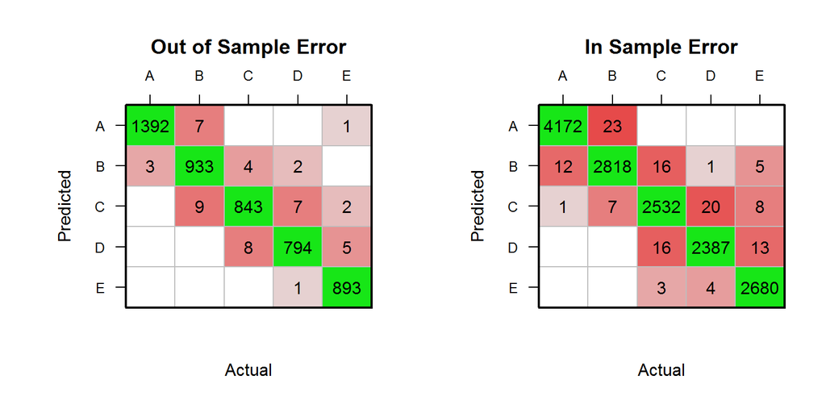

| Accuracy | Kappa | AccuracyLower | AccuracyUpper | AccuracyNull | AccuracyPValue | McnemarPValue |
| --- | --- | --- | --- | --- | --- | --- |
| 0.9900 | 0.9874 | 0.9868 | 0.9926 | 0.2855 | 0.0000 | NaN |

Table: Overall Statistics

|  | Class: A | Class: B | Class: C | Class: D | Class: E |
| --- | --- | --- | --- | --- | --- |
| Sensitivity | 0.9943 | 0.9904 | 0.9791 | 0.9839 | 0.9989 |
| Specificity | 0.9991 | 0.9960 | 0.9970 | 0.9976 | 0.9980 |
| Pos Pred Value | 0.9978 | 0.9831 | 0.9860 | 0.9876 | 0.9911 |
| Neg Pred Value | 0.9977 | 0.9977 | 0.9956 | 0.9968 | 0.9998 |
| Prevalence | 0.2855 | 0.1921 | 0.1756 | 0.1646 | 0.1823 |
| Detection Rate | 0.2838 | 0.1903 | 0.1719 | 0.1619 | 0.1821 |
| Detection Prevalence | 0.2845 | 0.1935 | 0.1743 | 0.1639 | 0.1837 |
| Balanced Accuracy | 0.9967 | 0.9932 | 0.9881 | 0.9907 | 0.9984 |

Table: Statistics by Class

**Confusion Matrix for 1% tolerance for the second model**

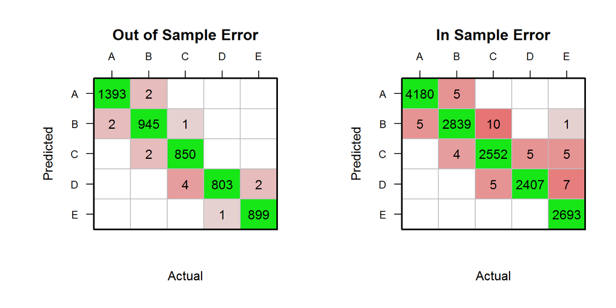

| Accuracy | Kappa | AccuracyLower | AccuracyUpper | AccuracyNull | AccuracyPValue | McnemarPValue |
| --- | --- | --- | --- | --- | --- | --- |
| 0.9971 | 0.9964 | 0.9952 | 0.9984 | 0.2845 | 0.0000 | NaN |

Table: Overall Statistics

|  | Class: A | Class: B | Class: C | Class: D | Class: E |
| --- | --- | --- | --- | --- | --- |
| Sensitivity | 0.9986 | 0.9968 | 0.9977 | 0.9926 | 0.9989 |
| Specificity | 0.9994 | 0.9990 | 0.9988 | 0.9998 | 0.9995 |
| Pos Pred Value | 0.9986 | 0.9958 | 0.9942 | 0.9988 | 0.9978 |
| Neg Pred Value | 0.9994 | 0.9992 | 0.9995 | 0.9985 | 0.9998 |
| Prevalence | 0.2845 | 0.1933 | 0.1737 | 0.1650 | 0.1835 |
| Detection Rate | 0.2841 | 0.1927 | 0.1733 | 0.1637 | 0.1833 |
| Detection Prevalence | 0.2845 | 0.1935 | 0.1743 | 0.1639 | 0.1837 |
| Balanced Accuracy | 0.9990 | 0.9979 | 0.9982 | 0.9962 | 0.9992 |

Table: Statistics by Class

**Confusion Matrix for 2% tolerance for the second model**

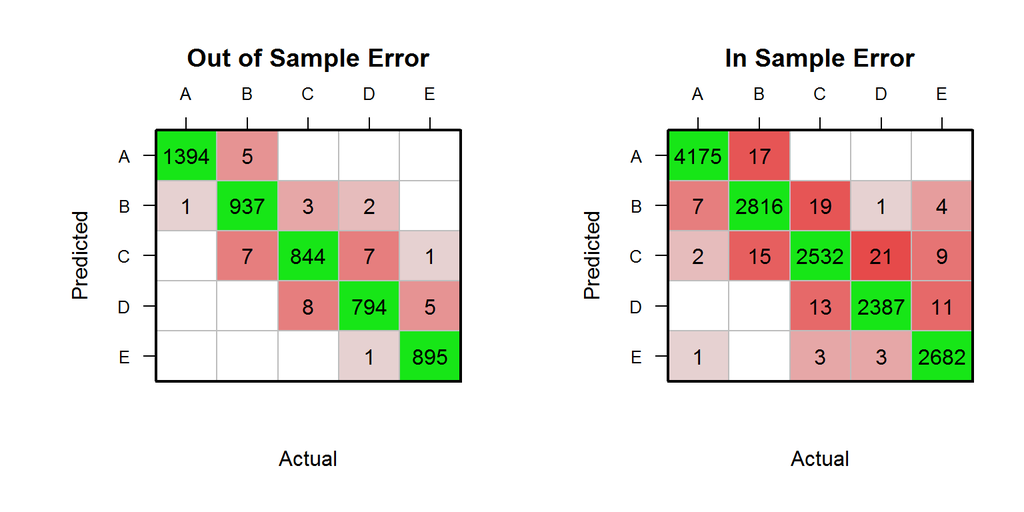

| Accuracy | Kappa | AccuracyLower | AccuracyUpper | AccuracyNull | AccuracyPValue | McnemarPValue |
| --- | --- | --- | --- | --- | --- | --- |
| 0.9918 | 0.9897 | 0.9889 | 0.9942 | 0.2853 | 0.0000 | NaN |

Table: Overall Statistics

|  | Class: A | Class: B | Class: C | Class: D | Class: E |
| --- | --- | --- | --- | --- | --- |
| Sensitivity | 0.9964 | 0.9936 | 0.9825 | 0.9839 | 0.9989 |
| Specificity | 0.9997 | 0.9970 | 0.9973 | 0.9976 | 0.9985 |
| Pos Pred Value | 0.9993 | 0.9874 | 0.9871 | 0.9876 | 0.9933 |
| Neg Pred Value | 0.9986 | 0.9985 | 0.9963 | 0.9968 | 0.9998 |
| Prevalence | 0.2853 | 0.1923 | 0.1752 | 0.1646 | 0.1827 |
| Detection Rate | 0.2843 | 0.1911 | 0.1721 | 0.1619 | 0.1825 |
| Detection Prevalence | 0.2845 | 0.1935 | 0.1743 | 0.1639 | 0.1837 |
| Balanced Accuracy | 0.9981 | 0.9953 | 0.9899 | 0.9907 | 0.9987 |

Table: Statistics by Class

**Confusion Matrix for best fit with interaction depth of 12, 500 threes, and shrinkage of 0.1**

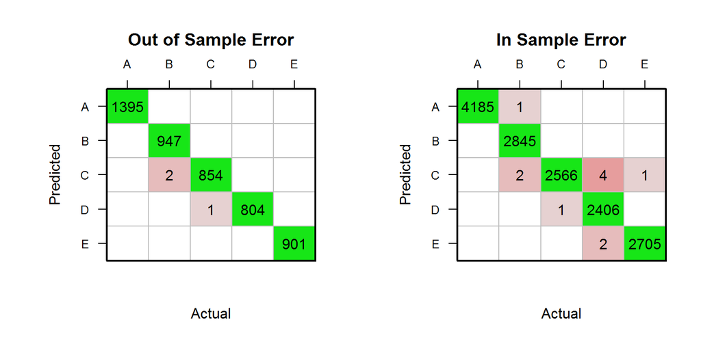

| Accuracy | Kappa | AccuracyLower | AccuracyUpper | AccuracyNull | AccuracyPValue | McnemarPValue |
| --- | --- | --- | --- | --- | --- | --- |
| 0.9994 | 0.9992 | 0.9982 | 0.9999 | 0.2845 | 0.0000 | NaN |

Table: Overall Statistics

|  | Class: A | Class: B | Class: C | Class: D | Class: E |
| --- | --- | --- | --- | --- | --- |
| Sensitivity | 1.0000 | 1.0000 | 0.9977 | 0.9988 | 1.0000 |
| Specificity | 1.0000 | 0.9995 | 0.9998 | 1.0000 | 1.0000 |
| Pos Pred Value | 1.0000 | 0.9979 | 0.9988 | 1.0000 | 1.0000 |
| Neg Pred Value | 1.0000 | 1.0000 | 0.9995 | 0.9998 | 1.0000 |
| Prevalence | 0.2845 | 0.1931 | 0.1746 | 0.1642 | 0.1837 |
| Detection Rate | 0.2845 | 0.1931 | 0.1741 | 0.1639 | 0.1837 |
| Detection Prevalence | 0.2845 | 0.1935 | 0.1743 | 0.1639 | 0.1837 |
| Balanced Accuracy | 1.0000 | 0.9997 | 0.9987 | 0.9994 | 1.0000 |

Table: Statistics by Class

**Confusion Matrix for best fit with interaction depth of 12, 1000 threes, and shrinkage of 0.05**

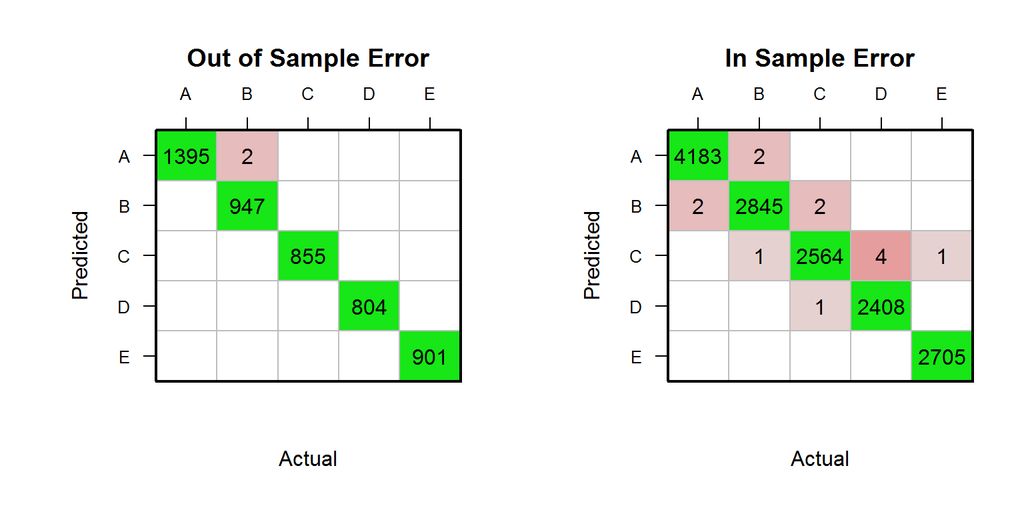

[output not shown]

Table: Overall Statistics

|  | Class: A | Class: B | Class: C | Class: D | Class: E |
| --- | --- | --- | --- | --- | --- |
| Sensitivity | 0.9986 | 1.0000 | 1.0000 | 1.0000 | 1.0000 |
| Specificity | 1.0000 | 0.9995 | 1.0000 | 1.0000 | 1.0000 |
| Pos Pred Value | 1.0000 | 0.9979 | 1.0000 | 1.0000 | 1.0000 |
| Neg Pred Value | 0.9994 | 1.0000 | 1.0000 | 1.0000 | 1.0000 |
| Prevalence | 0.2849 | 0.1931 | 0.1743 | 0.1639 | 0.1837 |
| Detection Rate | 0.2845 | 0.1931 | 0.1743 | 0.1639 | 0.1837 |
| Detection Prevalence | 0.2845 | 0.1935 | 0.1743 | 0.1639 | 0.1837 |
| Balanced Accuracy | 0.9993 | 0.9997 | 1.0000 | 1.0000 | 1.0000 |

Table: Statistics by Class

From the tables we see that the GBM performs reasonably well on both models (best fit and with tolerance). Using the most simple model (Model 1, 2% tolerance, 200 iterations, complexity of the tree 4, and learning rate of 0.1), there exists a high accuracy (Kappa = 98.74%), in addition, that model is high sensivity and specifity. The best fit models have high accuracy, sensivity and specifity, in addition, that model is more complex.

### Unknown Test

The results from the unknown test are:

**First Model 1%**

```
##  [1] B A B A A E D B A A B C B A E E A B B B
## Levels: A B C D E
```

**First Model 2%**

```
##  [1] B A B A A E D B A A B C B A E E A B B B
## Levels: A B C D E
```

**Second Model 1%**

```
##  [1] B A B A A E D B A A B C B A E E A B B B
## Levels: A B C D E
```

**Second Model 2%**

```
##  [1] B A B A A E D B A A B C B A E E A B B B
## Levels: A B C D E
```

```
##  [1] B A B A A E D B A A B C B A E E A B B B
## Levels: A B C D E
```

```
##  [1] B A B A A E D B A A B C B A E E A B B B
## Levels: A B C D E
```

### References

[1] Friedman[GBM](http://statweb.stanford.edu/~jhf/ftp/stobst.pdf)  
[2] KUHN, M., & JOHNSON, K. (2013). Applied predictive modeling. New York, NY, Springer. http://dx.doi.org/10.1007/978-1-4614-6849-3.  
[3] Velloso, E.; Bulling, A.; Gellersen, H.; Ugulino, W.; Fuks, H. Qualitative Activity Recognition of Weight Lifting Exercises. Proceedings of 4th International Conference in Cooperation with SIGCHI (Augmented Human ’13) . Stuttgart, Germany: ACM SIGCHI, 2013. Read more: [Groupware](http://groupware.les.inf.puc-rio.br/har)  
[4] Library [Caret](http://topepo.github.io/caret/)